# Human Activity Prediction

YutongLIU

Oct 19 2016

## Project overview

Using wareable devices is now possible to collect a large amount of data about personal activity. In this project, our goal is to use this kind of data to predict the exercise manner, so that we can know how well they do the activity and this can help wareable device users to know their exercice performance more easily.

## Data set information

Refer to the [website](http://groupware.les.inf.puc-rio.br/har), this data set records the exercise performed by 6 male participants aged between 20-28 years old.

Participants were asked to perform one set of 10 repetitions of the Unilateral Dumbbell Biceps Curl in five different fashions:

| Class | Activity |
| --- | --- |
| A | exactly according to the speci cation |
| B | throwing the elbows to the front |
| C | lifting the dumbbell only halfway |
| D | lowering the dumbbell only halfway |
| E | throwing the hips to the front |

Class A corresponds to the specified execution of the exercise, while the other 4 classes correspond to common mistakes.

> Download the data set

```r
library(caret)
library(randomForest)
library(dplyr)
library(ggplot2)
```

Firstly, we downloaded and read in the data set. After a glance of the data, we found that there were different formats of missing value, so we re-read the data and set the NA string format.

```r
#set the working directory
if(!dir.exists("D:/Coursera/L8W4_assignment/"))
   {dir.create("D:/Coursera/L8W4_assignment/");
    setwd("D:/Coursera/L8W4_assignment")}

#download data set
url_training<-"https://d396qusza40orc.cloudfront.net/predmachlearn/pml-training.csv"

#download data set
download.file(url=url_training,destfile = "./pml_training.csv")

#read in the data set
pml_training<-read.csv(file = "./pml_training.csv",header = T,
                na.strings = c(""," ","NA","#DIV/0!"))
```

> Preprocess the data set

After loading the training data set, we take a look at it.

- It contains 160 variables and 19622 observations.

```r
#take a look at the data set
str(pml_training)
```

[output not shown]

- There are too many missing values, about 98% are missing value in several variables, so if we impute these missing values, the result won’t be satisfied.

```r
#count missing data
count_na<-is.na(pml_training)
summary(count_na)
```

[output not shown]

These variables contain too much noisy, so finally we removed these variales.

```r
count_na<-apply(pml_training,2,function(x) sum(is.na(x)))
pml_training<-pml_training[,which(count_na==0)]
```

```r
pml_clean<-pml_training[,8:length(pml_training)]
```

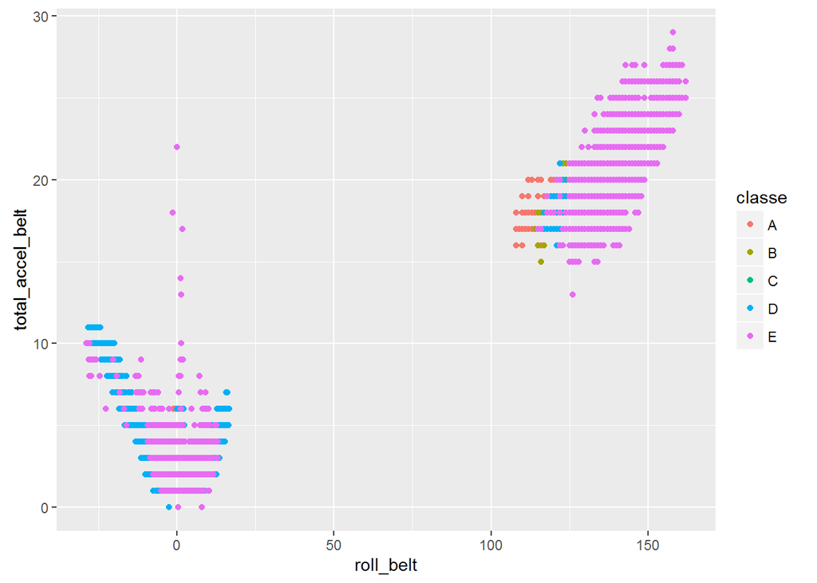

```r
qplot(roll_belt,total_accel_belt,colour=classe,data=pml_clean)
```

> Slicing the data set

We sliced the data set into training set and cross-validation set.

```r
# slicing the data set into 3 folds
set.seed(12345)
inTrain<-createDataPartition(y=pml_clean$classe,p=0.7,
                             list = FALSE)
train_set<-pml_clean[inTrain,]
crossval_set<-pml_clean[-inTrain,]
```

> Train the model

We train the model using decision tree and also random forest.

```r
#decision tree
model_dtree<-train(classe~.,data = train_set,method="rpart")

#random forest
model_rf<-randomForest(classe~.,data=train_set)
```

> Predict the outcome with cross-validation set

We predict the outcome with different models using cross-validation data set.

```r
outcome_dtree<-predict(model_dtree,crossval_set)
outcome_rf<-predict(model_rf,crossval_set)
```

> Evaluate the out of sample error

From the confusion matrix, we can conclude that the random forest model can predict the class of activity and identify the common mistake types better.

```r
#Using confusion matrix to evaluate the out of sample error
conmatrix_dtree<-confusionMatrix(outcome_dtree,crossval_set$classe)
conmatrix_rf<-confusionMatrix(outcome_rf,crossval_set$classe)
```

| Model | Accuracy |
| --- | --- |
| decision tree | 0.4963466 |
| random forest | 0.9926933 |

```r
conmatrix_dtree$overall;
```

```
##       Accuracy          Kappa  AccuracyLower  AccuracyUpper   AccuracyNull
##   4.963466e-01   3.424644e-01   4.834920e-01   5.092049e-01   2.844520e-01
## AccuracyPValue  McnemarPValue
##  1.106634e-256            NaN
```

```r
conmatrix_rf$overall
```

```
##       Accuracy          Kappa  AccuracyLower  AccuracyUpper   AccuracyNull
##      0.9926933      0.9907560      0.9901704      0.9947072      0.2844520
## AccuracyPValue  McnemarPValue
##      0.0000000            NaN
```

```r
url_testing<-"https://d396qusza40orc.cloudfront.net/predmachlearn/pml-testing.csv"
download.file(url=url_testing,destfile = "./pml_testing.csv")
pml_testing<-read.csv(file = "./pml_testing.csv",header = T,
                      na.strings = c(""," ","NA","#DIV/0!"))

# data preprocessing (same with the training data set)
count_na<-apply(pml_testing,2,function(x) sum(is.na(x)))
pml_testing<-pml_testing[,which(count_na==0)]
testing_clean<-pml_testing[,8:length(pml_testing)]

outcome_test<-predict(model_rf,testing_clean)
```